# Analisis Variansi Dua Arah pada Dataset thaltb.dat.txt

Sahda Huwaidah Estiningtyas

2024-04-23

```
Dataset:  thaltb.dat.txt
Source: J.D. Klausner, S.Makonkawkeyoon, P.Akarasewi, et al (1996).
"The Effect of Thalidomide on the Pathogenesis of Human Immunodeficiency Virus Type 1 and M. Tuberculosis Infection", Journal of Acquired Immune Deficiency Syndroms and Human Retrovirology. Vol. 11, pp247-257.
Description: Effect of Thalidomide versus Placebo on weight gain in HIV+ subjects with and without TB.

Variables/Columns:
Treatment  7  /* 1=Thalidomide, 0=Placebo   */
TB status  14   /* 1=Positive,  0=Negative  */
Weight gain  18-21  /* Kilograms over 21-day period  */
```

### Menyiapkan dataset

```r
thaltb <- read.table("C:/Users/LENOVO/OneDrive/Documents/UNY/Semester 2/thaltb.dat.txt",header=F,col.names=c("treatment","tb","weight"))
thaltb$treatment <- factor(thaltb$treatment)
levels(thaltb$treatment) <- c("Placebo","Thalidomide")
thaltb$tb <- factor(thaltb$tb)
levels(thaltb$tb) <- c("Negative","Positive")
str(thaltb)
```

```
## 'data.frame':    32 obs. of  3 variables:
##  $ treatment: Factor w/ 2 levels "Placebo","Thalidomide": 2 2 2 2 2 2 2 2 1 1 ...
##  $ tb       : Factor w/ 2 levels "Negative","Positive": 2 2 2 2 2 2 2 2 2 2 ...
##  $ weight   : num  9 6 4.5 2 2.5 3 1 1.5 2.5 3.5 ...
```

```r
head(thaltb,n=3)
```

```
##     treatment       tb weight
## 1 Thalidomide Positive    9.0
## 2 Thalidomide Positive    6.0
## 3 Thalidomide Positive    4.5
```

# A. Membuat plot rata-rata respons dan memberikan interpretasi

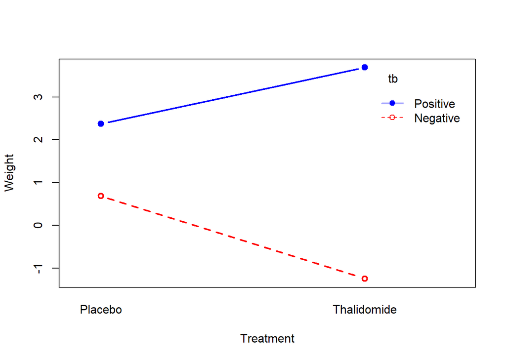

```r
attach(thaltb)
interaction.plot(x.factor=treatment, trace.factor=tb, response=weight, fun=mean, type="b", legend=TRUE, xlab="Treatment", ylab="Weight", pch=c(1,19), col=c("red", "blue"), lwd=2)
```

# B. Menentukan hipotesis nol dan hipotesis alternatif dalam kalimat dan simbol

### Hipotesis dalam kalimat:

**Uji Bagi Pengaruh interaksi**

- 𝐻0: Tidak ada pengaruh antara treatment dan status tuberculosis terhadap pertumbuhan berat badan
- 𝐻1: Ada pengaruh antara treatment dan status tuberculosis terhadap pertumbuhan berat badan

**Uji Pengaruh faktor A (Treatment)**

- 𝐻0: Tidak ada pengaruh antara treatment terhadap pertumbuhan berat badan
- 𝐻1: Ada pengaruh antara treatment terhadap pertumbuhan berat badan

**Uji Bagi Pengaruh faktor B (tb)**

- 𝐻0: Tidak ada pengaruh antara status tuberculosis terhadap pertumbuhan berat badan
- 𝐻1: Ada pengaruh antara status tuberculosis terhadap pertumbuhan berat badan

### Hipotesis dalam simbol:

**Hipotesis interaksi**

- 𝐻0: (∝ 𝛽)11 = (∝ 𝛽)12 = (∝ 𝛽)21 = (∝ 𝛽)22 = 0
- 𝐻1: ∃(∝ 𝛽)𝑖𝑗 ≠ 0, 𝑖 = 1,2;𝑗 = 1,2

**Hipotesis faktor A**

- 𝐻0: 𝑎1 = 𝑎2 = 0
- 𝐻1: ∃𝑎𝑖 ≠ 0, 𝑖 = 1,2

**Hipotesis faktor B**

- 𝐻0: 𝛽1 = 𝛽2 = 0
- 𝐻1: ∃𝛽𝑗 ≠ 0,𝑗 = 1,2

# C. Menentukan kriteria keputusan yang bersesuaian

### Uji Bagi Pengaruh interaksi

**Hipotesis:**

- 𝐻0: $(∝ 𝛽)_{11} = (∝ 𝛽)_{12} = (∝ 𝛽)_{21} = (∝ 𝛽)_{2} = 0$ (Tidak ada pengaruh antara treatment dan status tuberculosis terhadap pertumbuhan berat badan)
- 𝐻1: $∃(∝ 𝛽)_{ij} ≠ 0, i = 1,2; j = 1,2$ (Ada pengaruh antara treatment dan status tuberculosis terhadap pertumbuhan berat badan)

**Taraf signifikansi:**

- ∝ = 0.05

**Statistik uji:**

- $F_{AB} = \frac{KTAB}{KTG}$

**Kriteria Keputusan:**

- $a=2, b=2, n=8, F_{0.05((a-1)(b-1), ab(n-1))} = F_{0.05(1, 28)} = 4.196$
- $H_0$ ditolak jika $F_{AB} > 4.196$ atau $H_0$ ditolak jika p-value < 0.05

**Hitungan:**

$F_{AB} = \frac{KTAB}{KTG} = \frac{JKAB/(a-1)(b-1)}{JKG/ab(n-1)} = \frac{21.125⁄1}{100.3125⁄28} = 5.89657$

```r
# Dengan Program R
a <- nlevels(treatment)
a
```

```
## [1] 2
```

```r
b <- nlevels(tb)
b
```

```
## [1] 2
```

```r
n = 8
n
```

```
## [1] 8
```

```r
qf(0.95, df1=(a-1)*(b-1), df2=a*b*(n-1))
```

```
## [1] 4.195972
```

```r
p.value <- 1-pf(5.89657, df1=(a-1)*(b-1), df2=a*b*(n-1))
p.value
```

```
## [1] 0.02184744
```

**Kesimpulan:**

$F_{AB} = 5.89657, p-value = 0.0218$

Oleh karena $F_{AB} = 5.89657 > 4.196$ atau p-value = 0.0218 < 0.05, maka $H_0$ ditolak. Sehingga ada pengaruh antara treatment dan status tuberculosis terhadap pertumbuhan berat badan.

### Uji Bagi Pengaruh faktor A (Treatment)

**Hipotesis:**

- 𝐻0: $a_{1} = a_{2} = 0$ (Tidak ada pengaruh antara treatment terhadap pertumbuhan berat badan)
- 𝐻1: $∃a_{i} ≠ 0, i = 1,2$ (Ada pengaruh antara treatment terhadap pertumbuhan berat badan)

**Taraf signifikansi:**

- ∝ = 0.05

**Statistik uji:**

- $F_{A} = \frac{KTA}{KTG}$

**Kriteria Keputusan:**

- $a=2, b=2, n=8, F_{0.05((a-1), ab(n-1))} = F_{0.05(1, 28)} = 4.196$
- $H_0$ ditolak jika $F_{A} > 4.196$ atau $H_0$ ditolak jika p-value < 0.05

**Hitungan:**

$F_{A} = \frac{KTA}{KTG} = \frac{JKA/(a-1)}{JKG/ab(n-1)} = \frac{0.78125⁄1}{100.3125⁄28} = 0.21807$

```r
# Dengan Program R
qf(0.95, df1=(a-1)*(b-1), df2=a*b*(n-1))
```

```
## [1] 4.195972
```

```r
p.value.A <- 1-pf(0.21807, df1=(a-1)*(b-1), df2=a*b*(n-1))
p.value.A
```

```
## [1] 0.644128
```

**Kesimpulan:**

$F_{A} = 0.21807, p-value = 0.644128$

Oleh karena $F_{A} = 0.21807 < 4.196$ atau p-value = 0.644128 > 0.05, maka $H_0$ tidak ditolak. Sehingga tidak ada pengaruh antara treatment terhadap pertumbuhan berat badan.

### Uji Bagi Pengaruh faktor B (tb)

**Hipotesis:**

- 𝐻0: $𝛽_{1} = 𝛽_{2} = 0$ (Tidak ada pengaruh antara status tuberculosis terhadap pertumbuhan berat badan)
- 𝐻1: $∃𝛽_{j} ≠ 0, j = 1,2$ (Ada pengaruh antara status tuberculosis terhadap pertumbuhan berat badan)

**Taraf signifikansi:**

- ∝ = 0.05

**Statistik uji:**

- $F_{B} = \frac{KTB}{KTG}$

**Kriteria Keputusan:**

- $a=2, b=2, n=8, F_{0.05((b-1), ab(n-1))} = F_{0.05(1, 28)} = 4.196$
- $H_0$ ditolak jika $F_{B} > 4.196$ atau $H_0$ ditolak jika p-value < 0.05

**Hitungan:**

$F_{B} = \frac{KTB}{KTG} = \frac{JKB/(b-1)}{JKG/ab(n-1)} = \frac{87.78125/1}{100.3125⁄28} = 24.50218$

```r
# Dengan Program R
qf(0.95, df1=(a-1)*(b-1), df2=a*b*(n-1))
```

```
## [1] 4.195972
```

```r
p.value.B <- 1-pf(24.50218, df1=(a-1)*(b-1), df2=a*b*(n-1))
p.value.B
```

```
## [1] 3.179936e-05
```

**Kesimpulan:**

$F_{B} = 24.50218, p-value = 3.1799𝑒-05$

Oleh karena $F_{B} = 24.50218 > 4.196$ atau p-value = 3.1799𝑒-05 < 0.05, maka $H_0$ ditolak. Sehingga ada pengaruh antara status tuberculosis terhadap pertumbuhan berat badan.

# D. Membuat tabel ANOVA dan memberikan kesimpulan

```r
# ANOVA
options(digits = 10)
fit <- aov(weight ~ treatment*tb, data=thaltb)
summary(fit)
```

```
##              Df    Sum Sq  Mean Sq  F value     Pr(>F)
## treatment     1   0.78125  0.78125  0.21807   0.644129
## tb            1  87.78125 87.78125 24.50218 3.1799e-05 ***
## treatment:tb  1  21.12500 21.12500  5.89657   0.021847 *
## Residuals    28 100.31250  3.58259
## ---
## Signif. codes:  0 '***' 0.001 '**' 0.01 '*' 0.05 '.' 0.1 ' ' 1
```

**Kesimpulan Uji bagi Pengaruh Interaksi**

Karena $F_{AB} = 5.89657 > 4.196$ atau p-value = 0.0218 < 0.05, maka $H_0$ ditolak. Jadi, pada taraf signifikansi 0.05 dapat disimpulkan bahwa ada pengaruh antara treatment dan status tuberculosis terhadap pertumbuhan berat badan.

**Kesimpulan Uji bagi Pengaruh Utama Faktor A (Treatment)**

Karena $F_{A} = 0.21807 < 4.196$ atau p-value = 0.644128 > 0.05, maka $H_0$ tidak ditolak. Jadi, pada taraf signifikansi 0.05 dapat disimpulkan bahwa tidak ada pengaruh antara treatment terhadap pertumbuhan berat badan.

**Kesimpulan Uji bagi Pengaruh Utama Faktor B (tb)**

Karena $F_{B} = 24.50218 > 4.196$ atau p-value = 3.1799𝑒-05 < 0.05, maka $H_0$ ditolak. Jadi, pada taraf signifikansi 0.05 dapat disimpulkan bahwa ada pengaruh antara status tuberculosis terhadap pertumbuhan berat badan.

Kesimpulan tambahan:

- Hipotesis nol pada pengaruh interaksi ditolak, maka ada bukti interaksi yang signifikan.
- Hipotesis nol pada pengaruh faktor A tidak ditolak, maka pengaruh faktor A tidak dapat disimpulkan.
- Hipotesis nol pada pengaruh faktor B ditolak, maka pengaruh faktor B mungkin signifikan.

# E. Jika hipotesis pada pengaruh interaksi ditolak, lakukan perbandingan berganda dengan prosedur Tukey. Berikan kesimpulan dan rekomendasi. Gunakan 𝛼 = 0.05.

```r
TukeyHSD(fit, which = "treatment:tb", conf.level = 0.95)
```

```
##   Tukey multiple comparisons of means
##     95% family-wise confidence level
##
## Fit: aov(formula = weight ~ treatment * tb, data = thaltb)
##
## $`treatment:tb`
##                                              diff           lwr          upr
## Thalidomide:Negative-Placebo:Negative     -1.9375 -4.5214298932 0.6464298932
## Placebo:Positive-Placebo:Negative          1.6875 -0.8964298932 4.2714298932
## Thalidomide:Positive-Placebo:Negative      3.0000  0.4160701068 5.5839298932
## Placebo:Positive-Thalidomide:Negative      3.6250  1.0410701068 6.2089298932
## Thalidomide:Positive-Thalidomide:Negative  4.9375  2.3535701068 7.5214298932
## Thalidomide:Positive-Placebo:Positive      1.3125 -1.2714298932 3.8964298932
##                                                  p adj
## Thalidomide:Negative-Placebo:Negative     0.1953254270
## Placebo:Positive-Placebo:Negative         0.3023283519
## Thalidomide:Positive-Placebo:Negative     0.0181731421
## Placebo:Positive-Thalidomide:Negative     0.0034909773
## Thalidomide:Positive-Thalidomide:Negative 0.0000862901
## Thalidomide:Positive-Placebo:Positive     0.5177246371
```

# F. Jika hipotesis pada pengaruh interaksi tidak ditolak, lakukan perbandingan berganda dengan prosedur Tukey. Berikan kesimpulan dan rekomendasi. Gunakan 𝛼 = 0.05.

- Hipotesis pada pengaruh interaksi ditolak. Ada pengaruh interaksi antara treatment dan status tuberculosis terhadap perubahan berat badan.

# G. Pengecekan asumsi normalitas dan homogenitas variansi

```r
thaltb$int <- with(thaltb, interaction(treatment,tb), drop=TRUE)
levels(thaltb$int)
```

```
## [1] "Placebo.Negative"     "Thalidomide.Negative" "Placebo.Positive"
## [4] "Thalidomide.Positive"
```

```r
bartlett.test(weight~int, data=thaltb)
```

```
##
##  Bartlett test of homogeneity of variances
##
## data:  weight by int
## Bartlett's K-squared = 3.9312213, df = 3, p-value = 0.2689874
```

```r
grup1 <- subset(thaltb$weight, thaltb$int=="Placebo.Negative")
shapiro.test(grup1)
```

```
##
##  Shapiro-Wilk normality test
##
## data:  grup1
## W = 0.94495005, p-value = 0.6603397
```

```r
grup2 <- subset(thaltb$weight, thaltb$int=="Thalidomide.Negative")
shapiro.test(grup2)
```

```
##
##  Shapiro-Wilk normality test
##
## data:  grup2
## W = 0.8984978, p-value = 0.2800775
```

```r
grup3 <- subset(thaltb$weight, thaltb$int=="Placebo.Positive")
shapiro.test(grup3)
```

```
##
##  Shapiro-Wilk normality test
##
## data:  grup3
## W = 0.92183277, p-value = 0.444911
```

```r
grup4 <- subset(thaltb$weight, thaltb$int=="Thalidomide.Positive")
shapiro.test(grup4)
```

```
##
##  Shapiro-Wilk normality test
##
## data:  grup4
## W = 0.88860517, p-value = 0.2271259
```

```r
# Ekstrak residual
aov_residuals <- residuals(object=fit)
# Uji Shapiro-Wilk
shapiro.test(x=aov_residuals)
```

```
##
##  Shapiro-Wilk normality test
##
## data:  aov_residuals
## W = 0.93855079, p-value = 0.06810951
```